# Project Python Foundations: FoodHub Data Analysis

### Context

The number of restaurants in New York is increasing day by day. Lots of students and busy professionals rely on those restaurants due to their hectic lifestyles. Online food delivery service is a great option for them. It provides them with good food from their favorite restaurants. A food aggregator company FoodHub offers access to multiple restaurants through a single smartphone app.

The app allows the restaurants to receive a direct online order from a customer. The app assigns a delivery person from the company to pick up the order after it is confirmed by the restaurant. The delivery person then uses the map to reach the restaurant and waits for the food package. Once the food package is handed over to the delivery person, he/she confirms the pick-up in the app and travels to the customer's location to deliver the food. The delivery person confirms the drop-off in the app after delivering the food package to the customer. The customer can rate the order in the app. The food aggregator earns money by collecting a fixed margin of the delivery order from the restaurants.

### Objective

The food aggregator company has stored the data of the different orders made by the registered customers in their online portal. They want to analyze the data to get a fair idea about the demand of different restaurants which will help them in enhancing their customer experience. Suppose you are hired as a Data Scientist in this company and the Data Science team has shared some of the key questions that need to be answered. Perform the data analysis to find answers to these questions that will help the company to improve the business.

### Data Description

The data contains the different data related to a food order. The detailed data dictionary is given below.

### Data Dictionary

- order_id: Unique ID of the order
- customer_id: ID of the customer who ordered the food
- restaurant_name: Name of the restaurant
- cuisine_type: Cuisine ordered by the customer
- cost_of_the_order: Cost of the order
- day_of_the_week: Indicates whether the order is placed on a weekday or weekend (The weekday is from Monday to Friday and the weekend is Saturday and Sunday)
- rating: Rating given by the customer out of 5
- food_preparation_time: Time (in minutes) taken by the restaurant to prepare the food. This is calculated by taking the difference between the timestamps of the restaurant's order confirmation and the delivery person's pick-up confirmation.
- delivery_time: Time (in minutes) taken by the delivery person to deliver the food package. This is calculated by taking the difference between the timestamps of the delivery person's pick-up confirmation and drop-off information

### Let us start by importing the required libraries

```python
# Installing the libraries with the specified version.
# No need to install it as anaconda has below dependecies already installed.
#!pip install numpy==1.25.2 pandas==1.5.3 matplotlib==3.7.1 seaborn==0.13.1 -q --user
#!python -m pip install numpy==1.25.2 pandas==1.5.3 matplotlib==3.7.1 seaborn==0.13.1 -q --user
```

**Note**: *After running the above cell, kindly restart the notebook kernel and run all cells sequentially from the start again.*

```python
# import libraries for data manipulation
import numpy as np
import pandas as pd

# import libraries for data visualization
import matplotlib.pyplot as plt
import seaborn as sns
```

### Understanding the structure of the data

```python
# uncomment and run the following lines for Google Colab
# from google.colab import drive
# drive.mount('/content/drive')
```

```python
# Write your code here to read the data
df = pd.read_csv('D:/Dev/AI-ML-Course/PythonFundamentalProject-Submit/foodhub_order.csv')
```

```python
# Write your code here to view the first 5 rows
df.head()
```

|  | order_id | customer_id | restaurant_name | cuisine_type | cost_of_the_order | day_of_the_week | rating | food_preparation_time | delivery_time |
| --- | --- | --- | --- | --- | --- | --- | --- | --- | --- |
| 0 | 1477147 | 337525 | Hangawi | Korean | 30.75 | Weekend | Not given | 25 | 20 |
| 1 | 1477685 | 358141 | Blue Ribbon Sushi Izakaya | Japanese | 12.08 | Weekend | Not given | 25 | 23 |
| 2 | 1477070 | 66393 | Cafe Habana | Mexican | 12.23 | Weekday | 5 | 23 | 28 |
| 3 | 1477334 | 106968 | Blue Ribbon Fried Chicken | American | 29.20 | Weekend | 3 | 25 | 15 |
| 4 | 1478249 | 76942 | Dirty Bird to Go | American | 11.59 | Weekday | 4 | 25 | 24 |

### **Question 1:** How many rows and columns are present in the data? [0.5 mark]

```python
# Write your code here
df.shape
```

```
(1898, 9)
```

#### Observations:

### Data set from foodhub_order.csv contains 1898 rows and 9 columns

### **Question 2:** What are the datatypes of the different columns in the dataset? (The info() function can be used) [0.5 mark]

```python
# Write your code here
df.info()
```

```
<class 'pandas.core.frame.DataFrame'>
RangeIndex: 1898 entries, 0 to 1897
Data columns (total 9 columns):
 #   Column                 Non-Null Count  Dtype
---  ------                 --------------  -----
 0   order_id               1898 non-null   int64
 1   customer_id            1898 non-null   int64
 2   restaurant_name        1898 non-null   object
 3   cuisine_type           1898 non-null   object
 4   cost_of_the_order      1898 non-null   float64
 5   day_of_the_week        1898 non-null   object
 6   rating                 1898 non-null   object
 7   food_preparation_time  1898 non-null   int64
 8   delivery_time          1898 non-null   int64
dtypes: float64(1), int64(4), object(4)
memory usage: 133.6+ KB
```

#### Observations:

### Column datatypes are int64= Interger ( a whole number without a fraction), float64= floating point (or number with decimal), and Object= ( a string or character data type).

### For analysis -

#### we need to convert object data type to str where it appears to be label

#### In case of numberic data with we need to convert it to float64

```python
# Convert object columns to str type to use as lables
df['restaurant_name'] = df['restaurant_name'].astype('string')
df['cuisine_type'] = df['cuisine_type'].astype('string')
df['day_of_the_week'] = df['day_of_the_week'].astype('string')
df.dtypes
```

```
order_id                          int64
customer_id                       int64
restaurant_name          string[python]
cuisine_type             string[python]
cost_of_the_order               float64
day_of_the_week          string[python]
rating                           object
food_preparation_time             int64
delivery_time                     int64
dtype: object
```

### object data types converted to string type

### **Question 3:** Are there any missing values in the data? If yes, treat them using an appropriate method. [1 mark]

```python
# Write your code here
print(df.isnull().sum())
df.isna()
```

```
order_id                 0
customer_id              0
restaurant_name          0
cuisine_type             0
cost_of_the_order        0
day_of_the_week          0
rating                   0
food_preparation_time    0
delivery_time            0
dtype: int64
```

|  | order_id | customer_id | restaurant_name | cuisine_type | cost_of_the_order | day_of_the_week | rating | food_preparation_time | delivery_time |
| --- | --- | --- | --- | --- | --- | --- | --- | --- | --- |
| 0 | False | False | False | False | False | False | False | False | False |
| 1 | False | False | False | False | False | False | False | False | False |
| 2 | False | False | False | False | False | False | False | False | False |
| 3 | False | False | False | False | False | False | False | False | False |
| 4 | False | False | False | False | False | False | False | False | False |
| ... | ... | ... | ... | ... | ... | ... | ... | ... | ... |
| 1893 | False | False | False | False | False | False | False | False | False |
| 1894 | False | False | False | False | False | False | False | False | False |
| 1895 | False | False | False | False | False | False | False | False | False |
| 1896 | False | False | False | False | False | False | False | False | False |
| 1897 | False | False | False | False | False | False | False | False | False |

1898 rows × 9 columns

#### Observations:

### There are no null values in Data set

### There are no NAN values for numeric data

### **Question 4:** Check the statistical summary of the data. What is the minimum, average, and maximum time it takes for food to be prepared once an order is placed? [2 marks]

```python
# Write your code here
df.describe().T
```

|  | count | mean | std | min | 25% | 50% | 75% | max |
| --- | --- | --- | --- | --- | --- | --- | --- | --- |
| order_id | 1898.0 | 1.477496e+06 | 548.049724 | 1476547.00 | 1477021.25 | 1477495.50 | 1.477970e+06 | 1478444.00 |
| customer_id | 1898.0 | 1.711685e+05 | 113698.139743 | 1311.00 | 77787.75 | 128600.00 | 2.705250e+05 | 405334.00 |
| cost_of_the_order | 1898.0 | 1.649885e+01 | 7.483812 | 4.47 | 12.08 | 14.14 | 2.229750e+01 | 35.41 |
| food_preparation_time | 1898.0 | 2.737197e+01 | 4.632481 | 20.00 | 23.00 | 27.00 | 3.100000e+01 | 35.00 |
| delivery_time | 1898.0 | 2.416175e+01 | 4.972637 | 15.00 | 20.00 | 25.00 | 2.800000e+01 | 33.00 |

#### Observations:

### Minimum food preparation time is 20 minutes

### Average food preparation time is 27 minutes (to be precise 27.371970 minutes)

### Maximum food preparation time is 35 minutes

### **Question 5:** How many orders are not rated? [1 mark]

```python
# Write the code here
# First get what values we have for rating
a = df['rating'].unique()
print(sorted(a))
# Non numeric value is 'Not given' which is not rated orders
count = df['rating'].value_counts()['Not given']
print(count)
```

```
['3', '4', '5', 'Not given']
736
```

#### Observations:

### There are total 736 orders that are not rated out of total 1898 orders

### Data Cleaning

#### Check for Missing Values: Identify missing values and decide how to handle them (e.g., imputation, removal).

#### Data Type Conversion: Ensure data types are appropriate for analysis (e.g., convert categorical variables to category type).

#### There is significant amount of order not rated.

#### For analysis it would be required to convert rating column to number

```python
# Convert 'Not given' to NaN
df['rating'] = df['rating'].replace('Not given', pd.NA)
# Convert the column to numeric type
df['rating'] = pd.to_numeric(df['rating'], errors='coerce')

# check how it looks now
df.info()
```

```
<class 'pandas.core.frame.DataFrame'>
RangeIndex: 1898 entries, 0 to 1897
Data columns (total 9 columns):
 #   Column                 Non-Null Count  Dtype
---  ------                 --------------  -----
 0   order_id               1898 non-null   int64
 1   customer_id            1898 non-null   int64
 2   restaurant_name        1898 non-null   string
 3   cuisine_type           1898 non-null   string
 4   cost_of_the_order      1898 non-null   float64
 5   day_of_the_week        1898 non-null   string
 6   rating                 1162 non-null   float64
 7   food_preparation_time  1898 non-null   int64
 8   delivery_time          1898 non-null   int64
dtypes: float64(2), int64(4), string(3)
memory usage: 133.6 KB
```

### Exploratory Data Analysis (EDA)

### Univariate Analysis

### **Question 6:** Explore all the variables and provide observations on their distributions. (Generally, histograms, boxplots, countplots, etc. are used for univariate exploration.) [9 marks]

```
# # Cost of Order vs Count
```

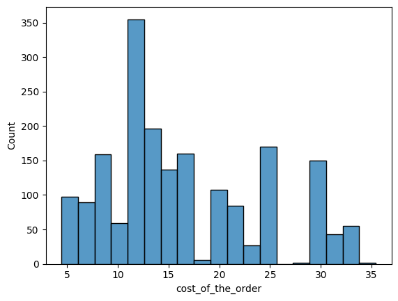

```
# # Cost of Order
```

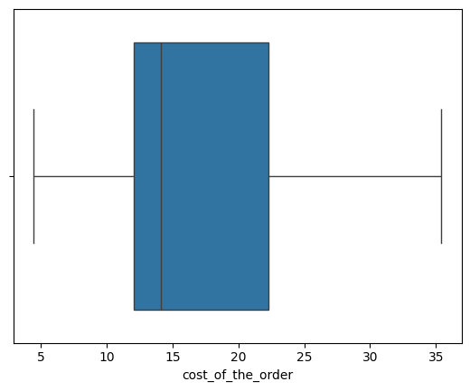

```
# # Day of the Week
```

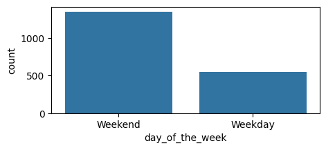

```python
# Write the code here
#
# # Cost of Order
# check the count of unique number of cost of orders, value counts, and countplot.
print ('# # Cost of Order vs Count')
sns.histplot(data=df,x='cost_of_the_order')
plt.show()
print ('# # Cost of Order')
sns.boxplot(data=df,x='cost_of_the_order')
plt.show()

# # Day of the Week
# check the count of unique number of Days of the week, value counts, and countplot.
df['day_of_the_week'].nunique()
print ('# # Day of the Week')
plt.figure(figsize = (5,2))
sns.countplot(data = df, x = 'day_of_the_week')
```

## **Oberservation:**

1. Significant number of orders fall between $12 to $16 range, this is a popular cost segment.
2. Nearly a third of all orders (29.24%) cost more than $20. This is a significant portion, and it indicates that many customers are making relatively high-value purchases.
3. Higher Demand on Weekends: There's significantly more demand on weekends (1351 orders) compared to weekdays (547 orders). This means customers are more likely to order food using the FoodHub app during the weekend.
4. Business Insights: The higher demand on weekends could be driven by multiple factors. People might have more free time, might be more likely to spend more time with family or friends, resulting in larger orders. Such trends can be used for inventory management, staffing needs, and promotional activities.
5. Resource Allocation: FoodHub could use this insight to better manage resources. For instance, ensuring enough delivery personnel on weekends to handle the increased number of orders.

```python
# value_counts: counts the occurrence of each unique value in the Series.
rating_counts = df["rating"].value_counts
rating_counts()
# Calculate NaN count
nan_count = df['rating'].isna().sum()
print (f'Rating Count={rating_counts()}')
print (f'Rating NaN Count={nan_count}')
```

```
Rating Count=rating
5.0    588
4.0    386
3.0    188
Name: count, dtype: int64
Rating NaN Count=736
```

```
# # Rating
```

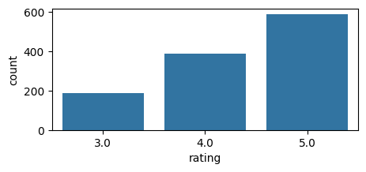

```python
print ('# # Rating')
plt.figure(figsize=(5,2))
sns.countplot(data=df, x='rating');
plt.show()
```

## **Oberservation:**

1. High Ratings: Among the orders that were rated, the majority of them have received high ratings (5 and 4). This is a positive sign and suggests that customers are generally satisfied with their orders.
2. Low Ratings: A smaller portion of orders have received a rating of 3, which could be considered average or below average.
3. Nearly a third of all orders (29.24%) cost more than $20. This is a significant portion, and it indicates that many customers are making relatively high-value purchases.

```
Unique Order Count = 1898
Unique Customers Count = 1200
Unique Restaurant Count = 178
# # Food Preparation time vs Count
```

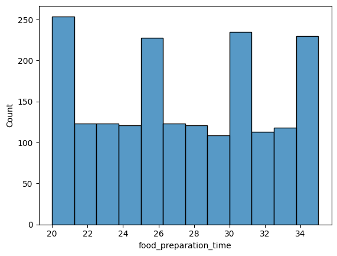

```
# # Food Preparation time
```

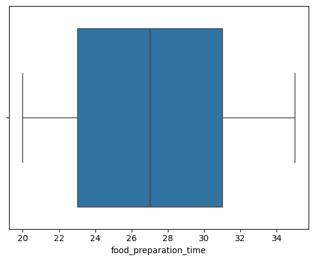

```
# # Delivery time vs Count
```

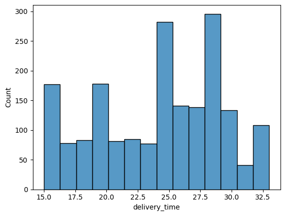

```
# # Delivery time
```

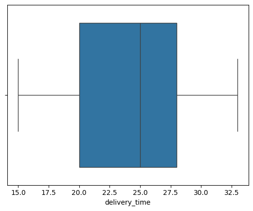

```
# # Delivery time vs Count
```

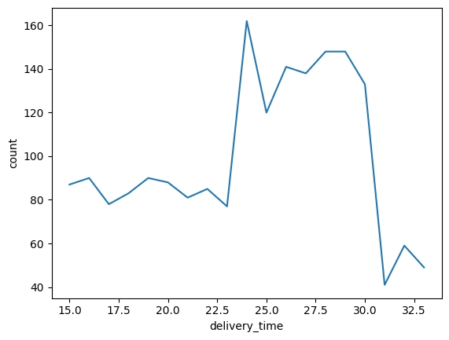

```python
#check the count of unique order IDs
unique_order_id = df['order_id'].nunique()
print(f'Unique Order Count = {unique_order_id}')
# check the count of unique number of customer IDs
unique_customer_id = df['customer_id'].nunique()
print(f'Unique Customers Count = {unique_customer_id}')

# check the count of unique number of restaurant names, value counts, and countplot.
unique_restaurant_name = df['restaurant_name'].nunique()
print(f'Unique Restaurant Count = {unique_restaurant_name}')

# # Food Preparation
# Visualize the Food preparation using a histplot and boxplot.
print ('# # Food Preparation time vs Count')
sns.histplot(data=df,x='food_preparation_time',stat='count')
plt.show()
print ('# # Food Preparation time')
sns.boxplot(data=df,x='food_preparation_time')
plt.show()

# Visualize the Delivery time using a histplot and boxplot.
print ('# # Delivery time vs Count')
sns.histplot(data=df,x='delivery_time')
plt.show()
print ('# # Delivery time')
sns.boxplot(data=df,x='delivery_time')
plt.show()

print ('# # Delivery time vs Count')
df_counts = df['delivery_time'].value_counts().reset_index()
df_counts.columns = ['delivery_time', 'count']
sns.lineplot(x='delivery_time', y='count', data=df_counts)
plt.show()
```

## **Oberservation:**

1. Food Preparation: The food preparation time data has central tendency.
2. Delivery Time: The delivery time data is negatively (left) skewed.

```
# # Restaurant Name Count
```

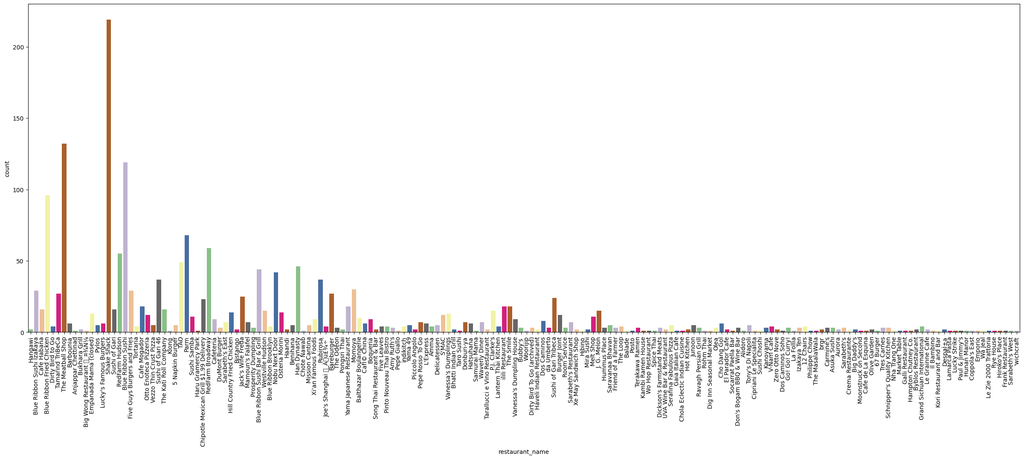

```
# # Cuisine Type Count
```

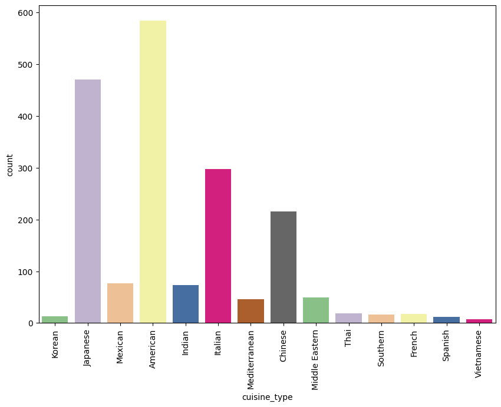

```python
# Ignore seaborn and matlib warnings
import warnings
warnings.filterwarnings("ignore")

# restaurant_name_counts = df["restaurant_name"].value_counts
# restaurant_name_counts()

print ('# # Restaurant Name Count')

plt.figure(figsize=(30,10))
sns.countplot(data=df, x='restaurant_name', palette='Accent')
plt.xticks(rotation=90);
plt.show()

# check the count of unique number of cuisine type, value counts, and countplot.
print ('# # Cuisine Type Count')
df['cuisine_type'].nunique()
cuisine_type_counts = df["cuisine_type"].value_counts
cuisine_type_counts()
plt.figure(figsize=(10,7))
sns.countplot(data=df, x='cuisine_type', palette='Accent')
plt.xticks(rotation=90);
```

### **Question 7**: Which are the top 5 restaurants in terms of the number of orders received? [1 mark]

```python
# Write the code here
# Group by 'restaurant_name' and count the number of orders, then sort in descending order
top_restaurants = df['restaurant_name'].value_counts().head(5)

print(top_restaurants)
```

```
restaurant_name
Shake Shack                  219
The Meatball Shop            132
Blue Ribbon Sushi            119
Blue Ribbon Fried Chicken     96
Parm                          68
Name: count, dtype: Int64
```

#### Observations:

### List of top 5 restaurants in terms of number of orders received

#### Shake Shack 219

#### The Meatball Shop 132

#### Blue Ribbon Sushi 119

#### Blue Ribbon Fried Chicken 96

### Shake Shack is #1 with order count as 219

### **Question 8**: Which is the most popular cuisine on weekends? [1 mark]

```python
# Write the code here
# Filter the data for weekend orders
weekend_orders = df[df['day_of_the_week'] == 'Weekend']

# Group by 'cuisine_type' and count the number of orders, then sort in descending order
most_popular_cuisine = weekend_orders['cuisine_type'].value_counts().idxmax()

print(f"The most popular cuisine on weekends is: {most_popular_cuisine}")
```

```
The most popular cuisine on weekends is: American
```

#### Observations:

### It appears from analysis that American cusine is the most popular one during weekends

### **Question 9**: What percentage of the orders cost more than 20 dollars? [2 marks]

```python
# Write the code here

# Count the number of orders with a cost greater than 20 dollars
orders_above_20 = df[df['cost_of_the_order'] > 20].shape[0]

# Calculate the total number of orders
total_orders = df.shape[0]

# Calculate the percentage of orders costing more than 20 dollars
percentage_above_20 = (orders_above_20 / total_orders) * 100

print(f"The percentage of orders that cost more than 20 dollars is: {percentage_above_20:.2f}%")
```

```
The percentage of orders that cost more than 20 dollars is: 29.24%
```

#### Observations:

### It appears that 29.24% of order are $20 or more

### This means majority of orders are below $20

### **Question 10**: What is the mean order delivery time? [1 mark]

```python
# Write the code here
# Calculate the mean of the 'delivery_time' column
mean_delivery_time = df['delivery_time'].mean()

print(f"The mean order delivery time is: {mean_delivery_time:.2f} minutes")
```

```
The mean order delivery time is: 24.16 minutes
```

#### Observations:

### It appears that mean delivery time is around 24.16 minutes

### **Question 11:** The company has decided to give 20% discount vouchers to the top 3 most frequent customers. Find the IDs of these customers and the number of orders they placed. [1 mark]

```python
# Write the code here
# Steps to Compute top 3 most frequent customer -
# Group by 'customer_id' and count the number of orders each customer has placed
customer_order_count = df.groupby('customer_id').size().reset_index(name='order_count')
# Sort the customers by the number of orders in descending order
sorted_customers = customer_order_count.sort_values(by='order_count', ascending=False)

# Extract the top 3 most frequent customers
top_3_customers = sorted_customers.head(3)

# Display the customer IDs and the number of orders they placed
print(top_3_customers)
```

```
     customer_id  order_count
116        52832           13
84         47440           10
333        83287            9
```

#### Observations:

### Customer ID 52832 is most frequent customer with total 13 order count

### Customer ID 47440 is 2nd most frequent customer with total 10 order count

### Customer ID 83287 is third most frequent customer with total 9 order count

### Multivariate Analysis

### **Question 12**: Perform a multivariate analysis to explore relationships between the important variables in the dataset. (It is a good idea to explore relations between numerical variables as well as relations between numerical and categorical variables) [10 marks]

```
# # Showing Correlation among key variables by ploting the heatmap
```

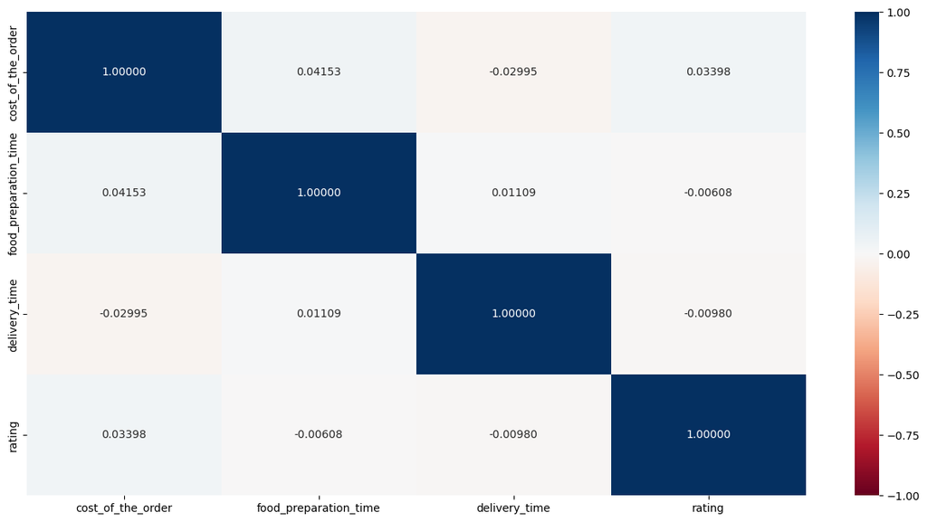

```
# # Day of the week vs Delivery Time
# Relationship between Day of the week and Delivery Time
```

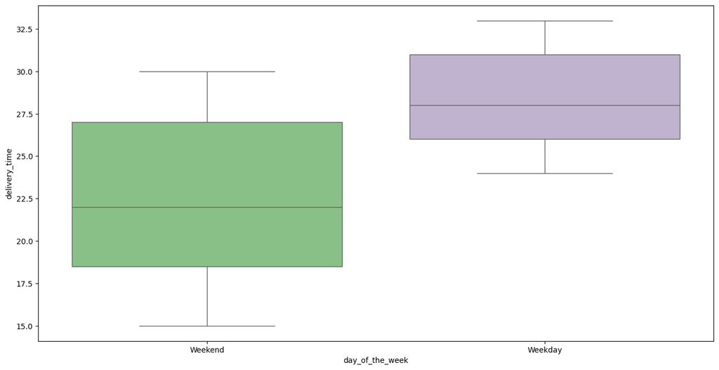

```
# # Rating vs Delivery Time
# Showing relationship between Rating and Delivery Time
```

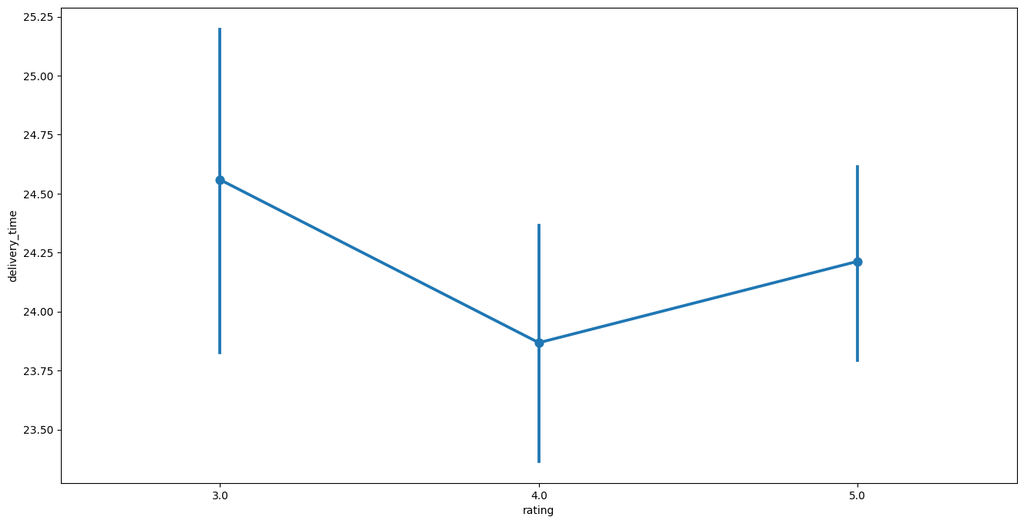

```
# # Rating vs Food preparation Time
# Relationship between Rating and Food preperation
```

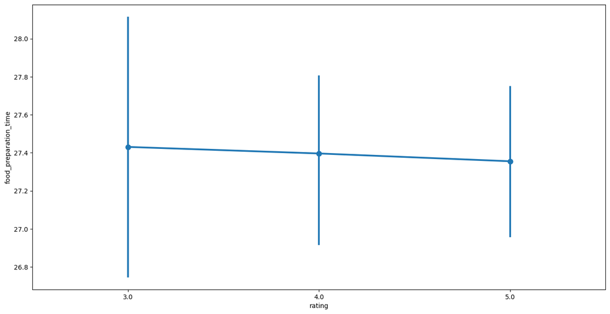

```
# # Rating vs Cost of the order
# Relationship between Rating and cost of the order
```

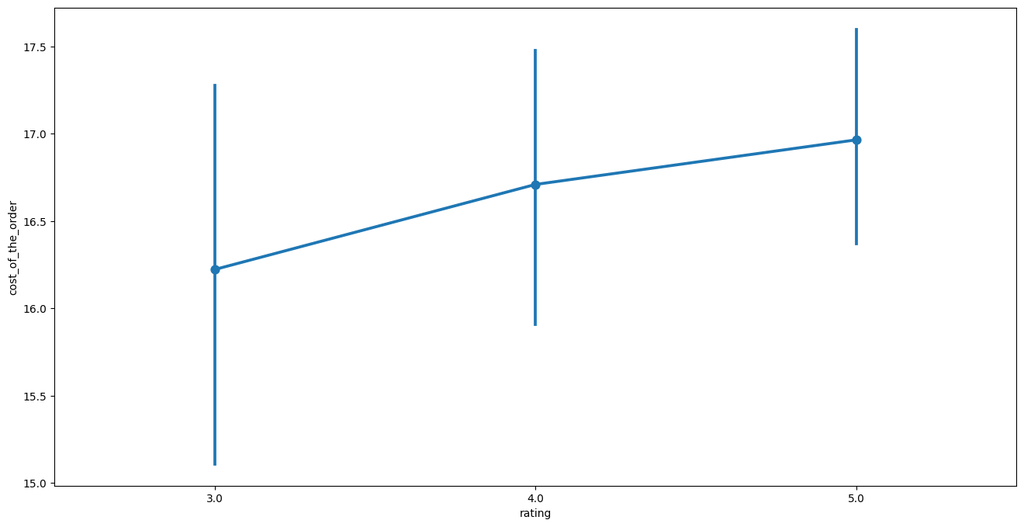

```
# # Cuisine vs Cost of the order
# Relationship between cost of the order and cuisine type
```

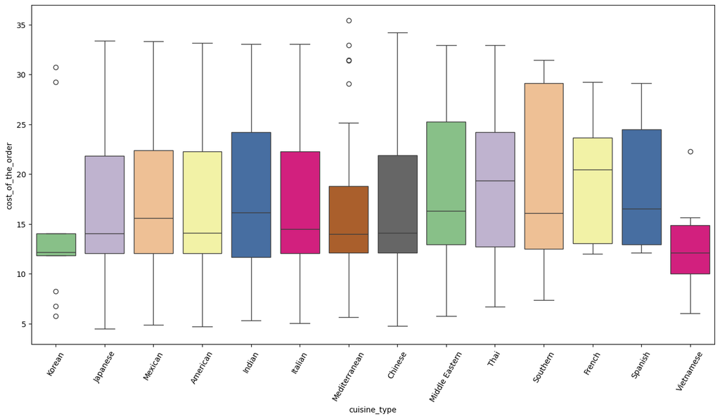

```
# # Food Preparation Time vs Cuisine Type
# Showing relationship between Food preparation and cuisine type
```

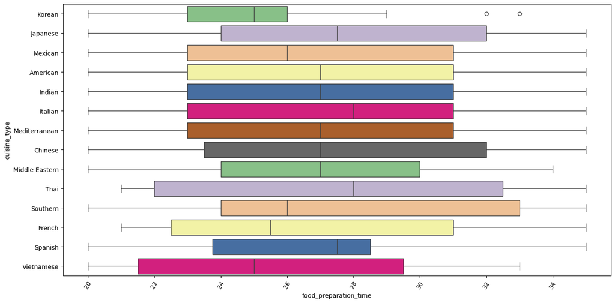

```
# Top 14 Restaurants names with total Cost of Order
```

```
restaurant_name
Shake Shack                      3579.53
The Meatball Shop                2145.21
Blue Ribbon Sushi                1903.95
Blue Ribbon Fried Chicken        1662.29
Parm                             1112.76
RedFarm Broadway                  965.13
RedFarm Hudson                    921.21
TAO                               834.50
Han Dynasty                       755.29
Blue Ribbon Sushi Bar & Grill     666.62
Rubirosa                          660.45
Sushi of Gari 46                  640.87
Nobu Next Door                    623.67
Five Guys Burgers and Fries       506.47
Name: cost_of_the_order, dtype: float64
```

```python
# Write the code here
# Ignore seaborn and matlib warnings
import warnings
warnings.filterwarnings("ignore")

print ('# # Showing Correlation among key variables by ploting the heatmap')
col_list = ['cost_of_the_order', 'food_preparation_time', 'delivery_time', 'rating']
plt.figure(figsize=(16, 8))
sns.heatmap(df[col_list].corr(), annot=True, vmin=-1, vmax=1, fmt=".5f", cmap="RdBu")
plt.show()

print ('# # Day of the week vs Delivery Time')
print ('# Relationship between Day of the week and Delivery Time')
plt.figure(figsize=(16, 8))
sns.boxplot (x = 'day_of_the_week', y = 'delivery_time', data = df, palette= 'Accent')
plt.show()

print ('# # Rating vs Delivery Time')
print ('# Showing relationship between Rating and Delivery Time')
plt.figure(figsize=(16, 8))
sns.pointplot(x = 'rating', y = 'delivery_time', data = df)
plt.show()

print ('# # Rating vs Food preparation Time')
print ('# Relationship between Rating and Food preperation')
plt.figure(figsize=(16, 8))
sns.pointplot(x = 'rating' , y = 'food_preparation_time' , data=df)
plt.show()

print ('# # Rating vs Cost of the order')
print ('# Relationship between Rating and cost of the order')
plt.figure(figsize=(16, 8))
sns.pointplot(x = 'rating' , y = 'cost_of_the_order' , data = df)
plt.show()

print ('# # Cuisine vs Cost of the order')
print ('# Relationship between cost of the order and cuisine type')
plt.figure(figsize=(16, 8))
sns.boxplot(x = "cuisine_type", y = "cost_of_the_order", data = df, palette = 'Accent')
plt.xticks(rotation = 60)
plt.show()

print ('# # Food Preparation Time vs Cuisine Type')
print ('# Showing relationship between Food preparation and cuisine type')
plt.figure(figsize=(16, 8))
sns.boxplot(x = 'food_preparation_time' , y = 'cuisine_type' , data= df, palette = 'Accent')
plt.xticks(rotation = 60)
plt.show()

# relationship of the total order cost for each restaurant and then sorting these totals.
print ('# Top 14 Restaurants names with total Cost of Order')
df.groupby(['restaurant_name'])['cost_of_the_order'].sum().sort_values(ascending = False).head(14)
```

### **Question 13:** The company wants to provide a promotional offer in the advertisement of the restaurants. The condition to get the offer is that the restaurants must have a rating count of more than 50 and the average rating should be greater than 4. Find the restaurants fulfilling the criteria to get the promotional offer. [3 marks]

```python
# Write the code here

# Find restaurants rating_count > 50
rating_counts = df["rating"].value_counts
#rest_names = df[df['rating']>50]['restaurant_name']
#print(rating_counts)
df_rating_count = df.groupby(['restaurant_name'])['rating'].count().sort_values(ascending = False).reset_index()
df_rating_count.head()
# Get the restaurant names that have rating count more than 50
rest_names = df_rating_count[df_rating_count['rating'] > 50]['restaurant_name']
print(rest_names)

# Filter to get the data of restaurants that have rating count more than 50
df_mean_4 = df[df['restaurant_name'].isin(rest_names)].copy()

# Group the restaurant names with their ratings and find the mean rating of each restaurant
df_mean_4.groupby(['restaurant_name'])['rating'].mean().sort_values(ascending = False).reset_index().dropna()

print(df_mean_4)
```

```
0                  Shake Shack
1            The Meatball Shop
2            Blue Ribbon Sushi
3    Blue Ribbon Fried Chicken
Name: restaurant_name, dtype: string
      order_id  customer_id            restaurant_name cuisine_type  \
3      1477334       106968  Blue Ribbon Fried Chicken     American
6      1477894       157711          The Meatball Shop      Italian
12     1476966       129969  Blue Ribbon Fried Chicken     American
15     1477414        66222                Shake Shack     American
19     1477354        67487          Blue Ribbon Sushi     Japanese
...        ...          ...                        ...          ...
1887   1476873       237616                Shake Shack     American
1888   1477353       106324          The Meatball Shop      Italian
1891   1476981       138586                Shake Shack     American
```

[output cut: 30 more lines]

#### Shake Shack

#### The Meatball Shop

#### Blue Ribbon Sushi

#### Blue Ribbon Fried Chicken

### **Question 14:** The company charges the restaurant 25% on the orders having cost greater than 20 dollars and 15% on the orders having cost greater than 5 dollars. Find the net revenue generated by the company across all orders. [3 marks]

```python
# Write the code here
# Need to create function to compute the revenue based on condition
def compute_revenue(cost):
    if cost > 20:
        return cost*0.25
    elif cost > 5:
        return cost*0.15
    else:
        return cost*0


df['Revenue'] = df['cost_of_the_order'].apply(compute_revenue)

#Function to get the total revenue
total_rev = df['Revenue'].sum()
print('The net revenue is around', round(total_rev, 2), 'dollars')
```

```
The net revenue is around 6166.3 dollars
```

#### Observations:

### Net Revenue generated by company across all of orders is $6166.3

### **Question 15:** The company wants to analyze the total time required to deliver the food. What percentage of orders take more than 60 minutes to get delivered from the time the order is placed? (The food has to be prepared and then delivered.) [2 marks]

```python
# Write the code here
# Calculate total delivery time and add a new column to the dataframe df to store the total delivery time
df['total_time'] = df['food_preparation_time'] + df['delivery_time']

#find the percentage of orders that have more than 60 minutes of total delivery time
df_greater_than_60 = df[df['total_time']>60]

print('The total number of orders that took more than 60 minutes to get delivered is:', df_greater_than_60.shape[0])

percentage = (df_greater_than_60.shape[0] / df.shape[0]) * 100

print("Percentage of orders that took more than 60 minutes to get delivered:", round(percentage, 2), '%')
```

```
The total number of orders that took more than 60 minutes to get delivered is: 200
Percentage of orders that took more than 60 minutes to get delivered: 10.54 %
```

#### Observations:

### Approximately 10.54% takes more than 60 minutes to get delivered from the time the order is placed.

### **Question 16:** The company wants to analyze the delivery time of the orders on weekdays and weekends. How does the mean delivery time vary during weekdays and weekends? [2 marks]

```python
# Write the code here
# Calculate the mean delivery time on weekends and print it
print('The mean delivery time on weekends is around',
      round(df[df['day_of_the_week'] == 'Weekend']['delivery_time'].mean()),
     'minutes')

# Calculate the mean delivery time on weekdays and print it
print('The mean delivery time on weekdays is around',
      round(df[df['day_of_the_week'] == 'Weekday']['delivery_time'].mean()),
     'minutes')
```

```
The mean delivery time on weekends is around 22 minutes
The mean delivery time on weekdays is around 28 minutes
```

#### Observations:

### Mean Delivery time on weekend is 22 minutes

### Mean Delivery time on weekdays is 28 minutes

#### Weekend delivery is faster than weekdays, if preparation time is assumed to be same, then difference in specifics of order (and traffic) contributes to difference in delivery times between weekend and weekdays

### Conclusion and Recommendations

### **Question 17:** What are your conclusions from the analysis? What recommendations would you like to share to help improve the business? (You can use cuisine type and feedback ratings to drive your business recommendations.) [6 marks]

### Conclusions:

### Conclusions:

#### * From the analysis of FoodHub's data, it's clear that the platform is providing a important service in a busy citywhere the demand for online food delivery is high. Usage of platform by so many customers and orders shows that the platform is populer and indicates the success of FoodHub's business model.

#### Key observations include:

1. Certain cuisines like American, Japanese, and Italian are very popular, suggesting a diverse customers with varied food preferences.
2. Restaurants with higher ratings are preferred by customers, suggesting the importance of quality and customer feedback in busines growth.
3. A majority of orders are placed during the weekends, indicating that FoodHub is a preferred choice for customers during weekends or holidays.
4. Orders above 20 dollar are good revenue generation channel due to the higher margin and need to explore improving sales of order above 20 dollar using promotions and bundles.
5. Some order are taking very long time and this needs to be imporved.

##### In conclusion, FoodHub's business is well-positioned in the online food delivery market, but there is potential for further growth and efficiency. Focusing on promoting high-rated restaurants, encouraging customer feedback with incentives on next order, adding more cuisine options, and improving delivery times could be key areas to consider for enhancing customer satisfaction and business expansion.

### Recommendations:

### Recommendations:

1. **Promote High Rating of Restaurants:** Advertise these restaurants more to boost customer satisfaction and provide incentives to existing restraurants to improve their rating.
2. **Investigate Delivery Time Issues and Execute Improvements :** Identify the issues behind slow delivery times, find causes and provide solutions to improve delivery times.
3. **Increase American and Japanese Cuisine Options**: Offer promotions to increase orders from these types of restaurants and partner with more restaurants offering these cuisines.
4. **Encourage Customers to Provide Ratings:** Provide incentives for customers to rate their orders, asking restaurants on how to get more customer ratings.
5. **Rewards Program:** Consider a program to reward frequent customers, encouraging them to order more frequently with some system of accumaliting point system to get free order after certian number of orders.
6. **Improve Revenue Generation:** Explore if multi laer fee structure could potentially increase revenue without negatively impacting customer orders.
7. **Advertize Campaign :** Invest in smart multi-platform advertizement campaign to increse customer base across multiple cuisines.
8. **Experiment with Driverthrough take out :** Experiment with Driver through takeout option at selected restaurants to lure customers in certain area like city center where drive through option could be popular.